# EXPLORATORY ANALYSIS OF RED WINE QUALITY by Najma Ashraf

# Univariate Analysis

### What is the structure of your dataset?

The dataset consists of 1599 observations of 12 variables(fixed.acidity,volatile.acidity,citric.acid,residual.sugar,chlorides,free.sulphur.dioxide,total.sulphur.dioxide,density,pH,sulphates,alcohol,quality).The variable quality is an ordered factor variable consisting of following levels (very bad)->(very excellent)

quality:0,1,2,3,4,5,6,7,8,9,10

*Most of the wine samples have a quality rating of 5(681 samples)* The maximum quality score given to a sample is 8(only 18 samples) *The mean pH level of the samples is 3.311*  
Most of the wine samples have a fixed acidity of around 7.10 g/dm^3

### What is/are the main feature(s) of interest in your dataset?

This dataset is different in the fact that some of the variables represent the same attribute of the sample.On doing a google search,I found that the total sulphur dioxide content is the sum of free and the bound forms.

Also,the total acidity of the wine is the sum of fixed and volatile acidity.Also,the important parameters that contribute to the quality is fixed acidity,pH,alcohol content

### What other features in the dataset do you think will help support your investigation into your feature(s) of interest?

It is not easy to ascertain the quality by using only the three factors mentioned above.There may be exceptional cases.Also the variable like sulphur dioxide content,which if present in excess quantities becomes evident in the taste of wine

### Did you create any new variables from existing variables in the dataset?

Yes,I did.I created a new variable total.acidity which is the sum of fixed and volatile acidity to study how the quality varies with the acid content. Since the quality scores take up many values,it is difficult to see trends across each level.So I grouped the scores upto 4 as faulty,upto 6 as average and greater than 6 as good wine.

### Of the features you investigated, were there any unusual distributions? Did you perform any operations on the data to tidy, adjust, or change the form of the data? If so, why did you do this?

1.The fixed and volatile acidity,total sulfur dioxide,alcohol and sulphates follow a long tail distribution

2.However,the density and pH values are normally distributed

3.There are lot of zero values in citric acid column

Yes,I transformed the all the long-tailed distributions to normal distribution by using log transform.

# Bivariate Plots Section

```
## [1] "data.frame"
```

```
## [1] "matrix"
```

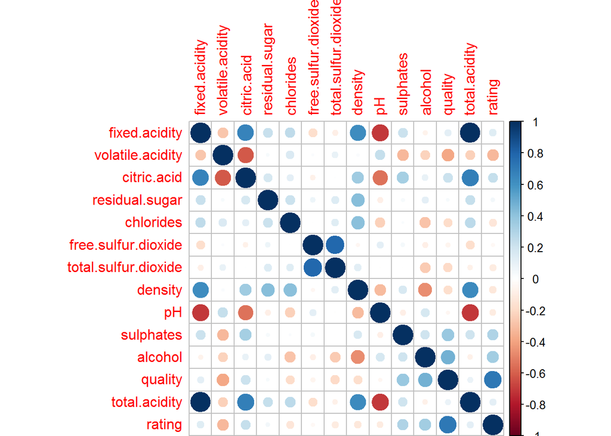

### Observations

1.The wine rating tends to decrease with increased volatile acidity  
2.A strong negative correlation between density and alcohol  
3.A strong negative correlation between fixed acidity and pH 4.The citric acid content is more in wines of better quality 5.The alcohol content also is more in the better quality wines Lets investigate the relationships in detail

```
## df$quality: 3
##    Min. 1st Qu.  Median    Mean 3rd Qu.    Max.
##   3.160   3.312   3.390   3.398   3.495   3.630
## --------------------------------------------------------
## df$quality: 4
##    Min. 1st Qu.  Median    Mean 3rd Qu.    Max.
##   2.740   3.300   3.370   3.382   3.500   3.900
## --------------------------------------------------------
## df$quality: 5
##    Min. 1st Qu.  Median    Mean 3rd Qu.    Max.
##   2.880   3.200   3.300   3.305   3.400   3.740
## --------------------------------------------------------
## df$quality: 6
##    Min. 1st Qu.  Median    Mean 3rd Qu.    Max.
##   2.860   3.220   3.320   3.318   3.410   4.010
## --------------------------------------------------------
## df$quality: 7
##    Min. 1st Qu.  Median    Mean 3rd Qu.    Max.
##   2.920   3.200   3.280   3.291   3.380   3.780
## --------------------------------------------------------
## df$quality: 8
##    Min. 1st Qu.  Median    Mean 3rd Qu.    Max.
##   2.880   3.162   3.230   3.267   3.350   3.720
```

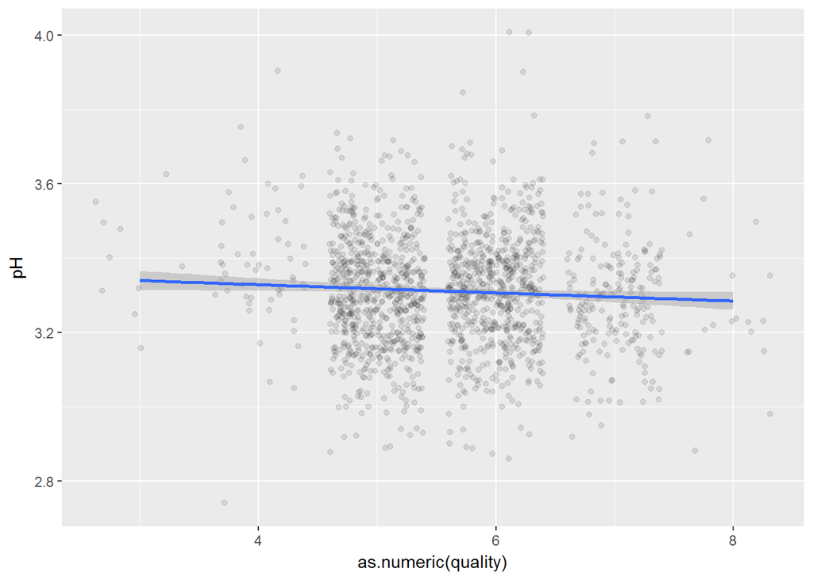

The median pH values are least for the best quality wines. We see that the median pH value for the best quality wines are only around 3.25. The pH affect flavor, aroma, color, tartrate precipitation, carbon dioxide absorption, malolactic fermentation, stability, ageablity, and fermentation rate. When the acid levels are too low,or the pH levels are high,your wine will lack body, the mouthfeel will be off, and it will taste weak or flabby.

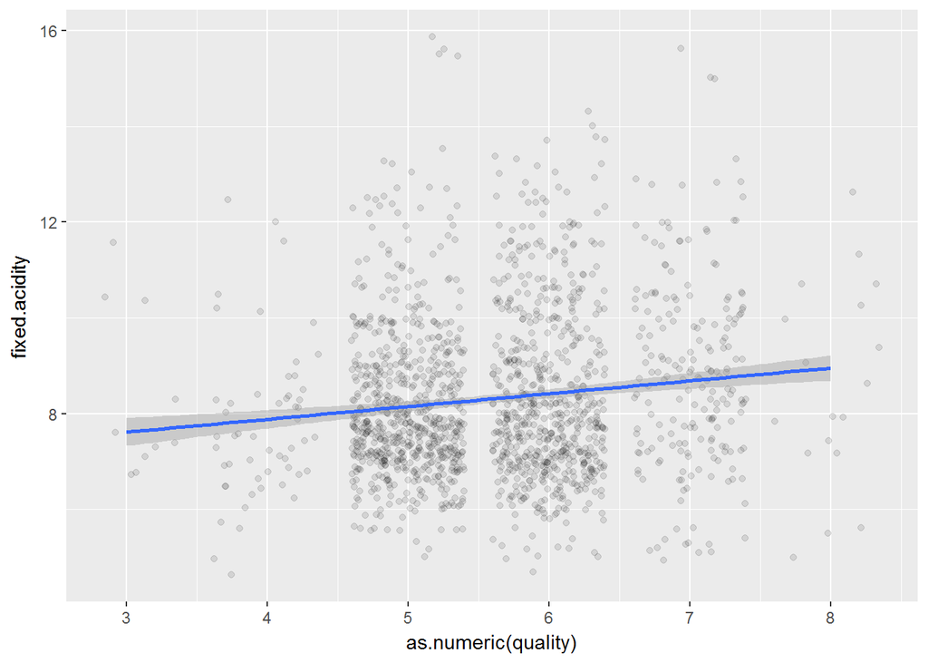

```
## df$quality: 3
##    Min. 1st Qu.  Median    Mean 3rd Qu.    Max.
##   6.700   7.150   7.500   8.360   9.875  11.600
## --------------------------------------------------------
## df$quality: 4
##    Min. 1st Qu.  Median    Mean 3rd Qu.    Max.
##   4.600   6.800   7.500   7.779   8.400  12.500
## --------------------------------------------------------
## df$quality: 5
##    Min. 1st Qu.  Median    Mean 3rd Qu.    Max.
##   5.000   7.100   7.800   8.167   8.900  15.900
## --------------------------------------------------------
## df$quality: 6
##    Min. 1st Qu.  Median    Mean 3rd Qu.    Max.
##   4.700   7.000   7.900   8.347   9.400  14.300
## --------------------------------------------------------
## df$quality: 7
##    Min. 1st Qu.  Median    Mean 3rd Qu.    Max.
##   4.900   7.400   8.800   8.872  10.100  15.600
## --------------------------------------------------------
## df$quality: 8
##    Min. 1st Qu.  Median    Mean 3rd Qu.    Max.
##   5.000   7.250   8.250   8.567  10.230  12.600
```

There does not seem to be any definite pattern in the fixed acidity levels across quality if we look at the mean and median values but overall,the fixed acidity values shows an increasing trend with increasing quality.

```
## df$quality: 3
##    Min. 1st Qu.  Median    Mean 3rd Qu.    Max.
##  0.4400  0.6475  0.8450  0.8845  1.0100  1.5800
## --------------------------------------------------------
## df$quality: 4
##    Min. 1st Qu.  Median    Mean 3rd Qu.    Max.
##   0.230   0.530   0.670   0.694   0.870   1.130
## --------------------------------------------------------
## df$quality: 5
##    Min. 1st Qu.  Median    Mean 3rd Qu.    Max.
##   0.180   0.460   0.580   0.577   0.670   1.330
## --------------------------------------------------------
## df$quality: 6
##    Min. 1st Qu.  Median    Mean 3rd Qu.    Max.
##  0.1600  0.3800  0.4900  0.4975  0.6000  1.0400
## --------------------------------------------------------
## df$quality: 7
##    Min. 1st Qu.  Median    Mean 3rd Qu.    Max.
##  0.1200  0.3000  0.3700  0.4039  0.4850  0.9150
## --------------------------------------------------------
## df$quality: 8
##    Min. 1st Qu.  Median    Mean 3rd Qu.    Max.
##  0.2600  0.3350  0.3700  0.4233  0.4725  0.8500
```

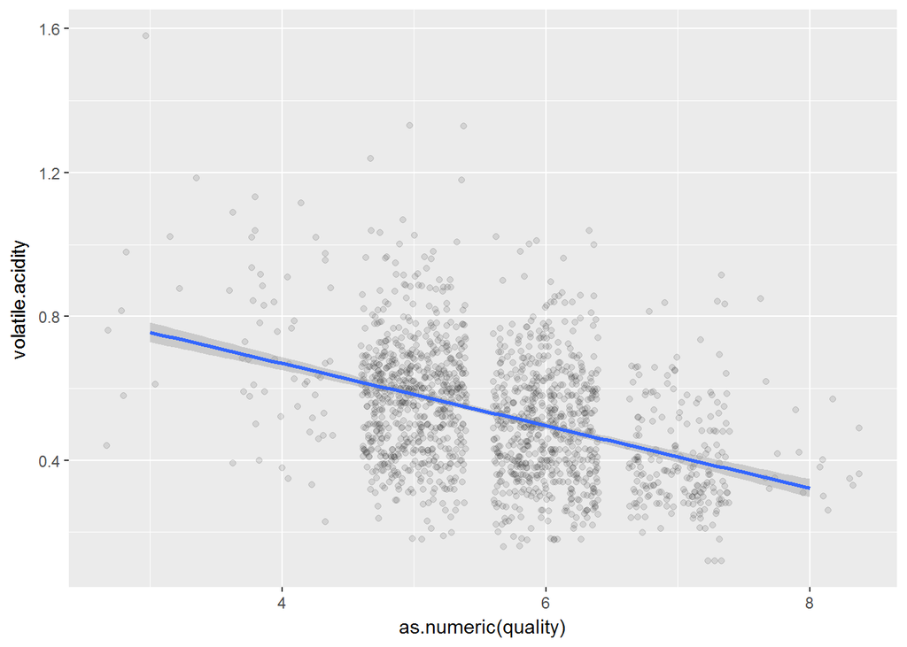

Better the quality,less the volatile acid content. There are different opinions as to what level of volatile acidity is appropriate for higher quality wine. Although too high a concentration is sure to leave an undesirable, ‘vinegar’ tasting wine, some wine’s acetic acid levels are developed to create a more ‘complex’, desirable taste.This explains the low levels of acetic acid content in better quality wines

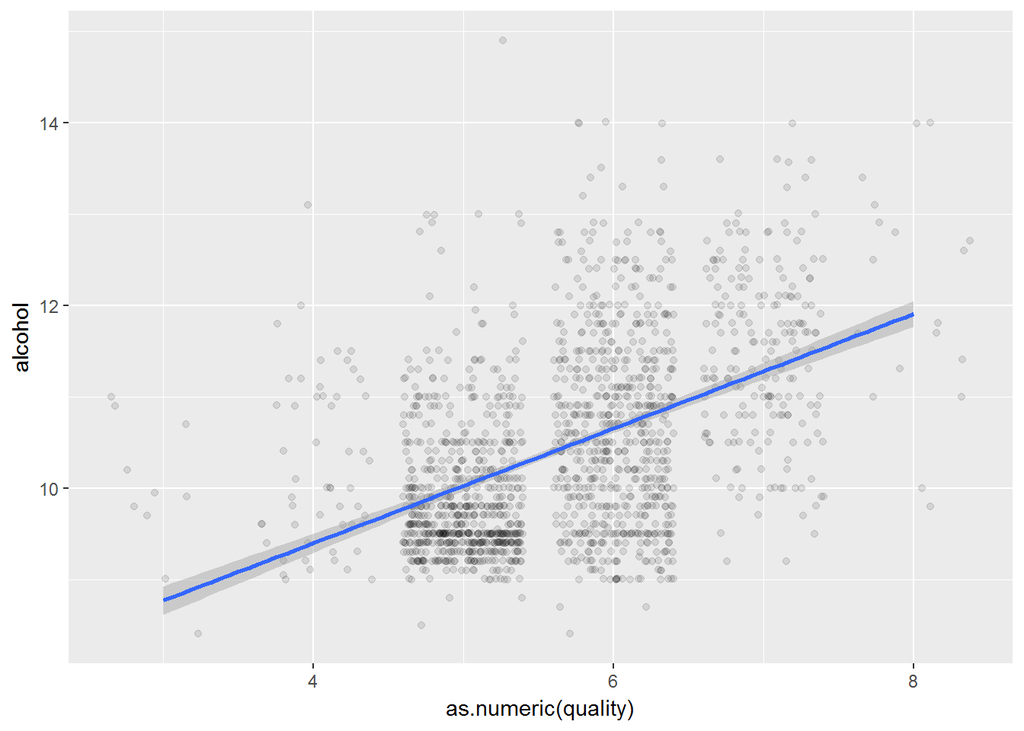

Surprisingly,wines with higher alcohol content are given better quality score

```
## df$quality: 3
##    Min. 1st Qu.  Median    Mean 3rd Qu.    Max.
##   8.400   9.725   9.925   9.955  10.580  11.000
## --------------------------------------------------------
## df$quality: 4
##    Min. 1st Qu.  Median    Mean 3rd Qu.    Max.
##    9.00    9.60   10.00   10.27   11.00   13.10
## --------------------------------------------------------
## df$quality: 5
##    Min. 1st Qu.  Median    Mean 3rd Qu.    Max.
##     8.5     9.4     9.7     9.9    10.2    14.9
## --------------------------------------------------------
## df$quality: 6
##    Min. 1st Qu.  Median    Mean 3rd Qu.    Max.
##    8.40    9.80   10.50   10.63   11.30   14.00
## --------------------------------------------------------
## df$quality: 7
##    Min. 1st Qu.  Median    Mean 3rd Qu.    Max.
##    9.20   10.80   11.50   11.47   12.10   14.00
## --------------------------------------------------------
## df$quality: 8
##    Min. 1st Qu.  Median    Mean 3rd Qu.    Max.
##    9.80   11.32   12.15   12.09   12.88   14.00
```

I investigated if the alcohol content is different in the best and worst quality wines.

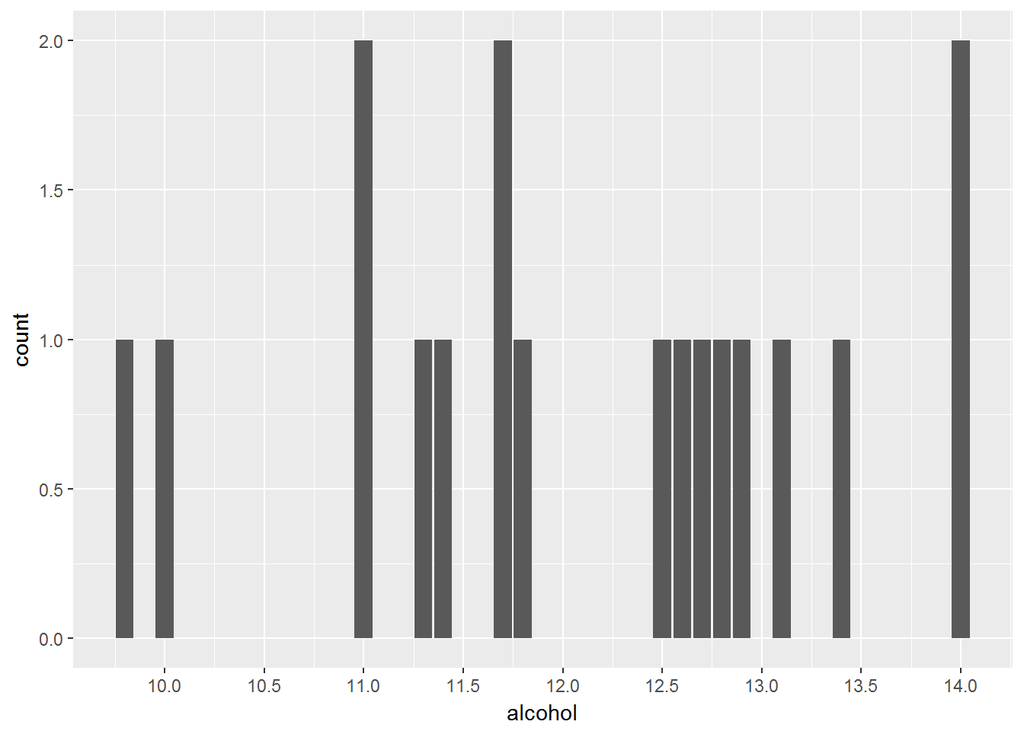

```
##    Min. 1st Qu.  Median    Mean 3rd Qu.    Max.
##    9.80   11.32   12.15   12.09   12.88   14.00
```

For most of the best quality wines,the mean alcohol content is 12.09% with most samples having 11%,11.75% or 14%

```
##    Min. 1st Qu.  Median    Mean 3rd Qu.    Max.
##   8.400   9.725   9.925   9.955  10.580  11.000
```

For the worst quality wines,the mean alcohol content is lower,i.e 9.955%

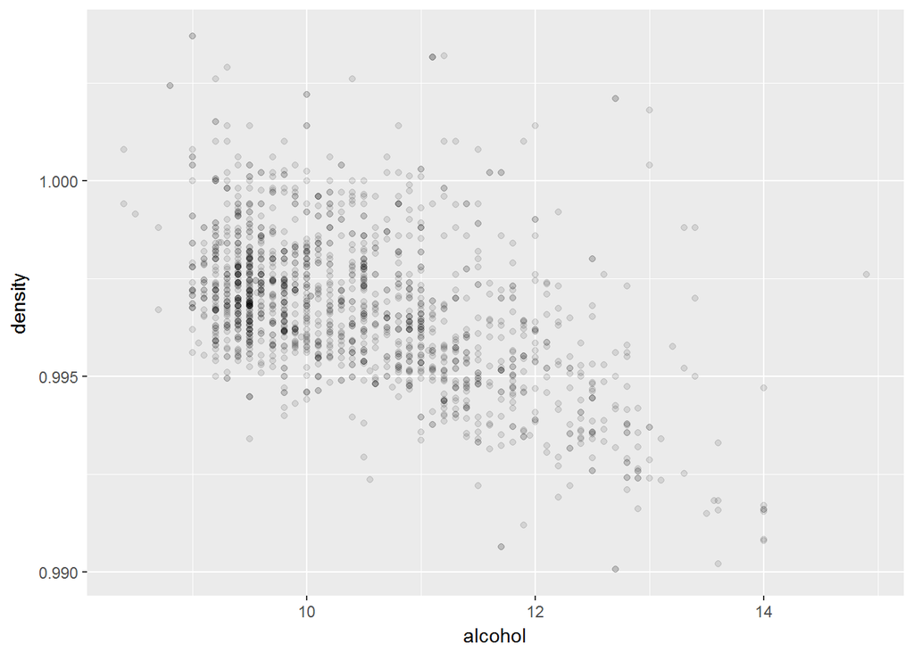

Corelation between alcohol and density

```r
cor(df$alcohol,
    df$density)
```

```
## [1] -0.4961798
```

Lets investigate how the citric acid content affects the quality of wine

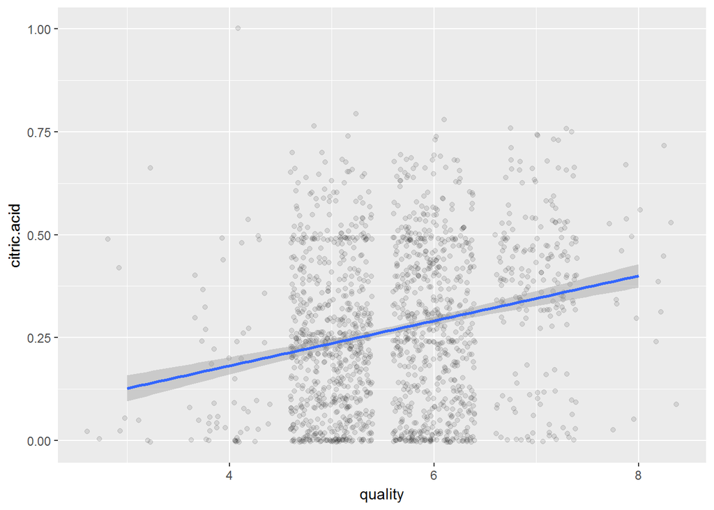

The citric acid content is useful for adding freshness and flavour to the wines.So,it is only expected that better quality wines have larger amount of citric acid content

```
## df$quality: 3
##    Min. 1st Qu.  Median    Mean 3rd Qu.    Max.
##  0.0000  0.0050  0.0350  0.1710  0.3275  0.6600
## --------------------------------------------------------
## df$quality: 4
##    Min. 1st Qu.  Median    Mean 3rd Qu.    Max.
##  0.0000  0.0300  0.0900  0.1742  0.2700  1.0000
## --------------------------------------------------------
## df$quality: 5
##    Min. 1st Qu.  Median    Mean 3rd Qu.    Max.
##  0.0000  0.0900  0.2300  0.2437  0.3600  0.7900
## --------------------------------------------------------
## df$quality: 6
##    Min. 1st Qu.  Median    Mean 3rd Qu.    Max.
##  0.0000  0.0900  0.2600  0.2738  0.4300  0.7800
## --------------------------------------------------------
## df$quality: 7
##    Min. 1st Qu.  Median    Mean 3rd Qu.    Max.
##  0.0000  0.3050  0.4000  0.3752  0.4900  0.7600
## --------------------------------------------------------
## df$quality: 8
##    Min. 1st Qu.  Median    Mean 3rd Qu.    Max.
##  0.0300  0.3025  0.4200  0.3911  0.5300  0.7200
```

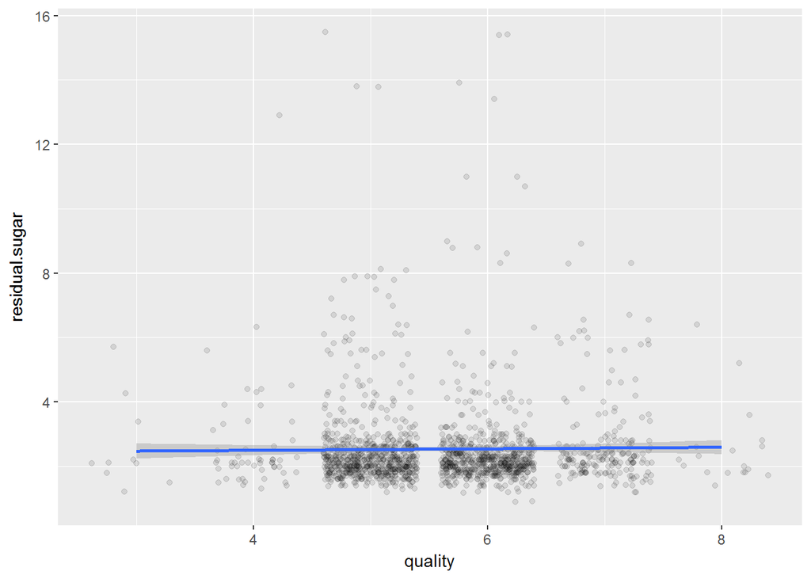

```
## df$quality: 3
##    Min. 1st Qu.  Median    Mean 3rd Qu.    Max.
##   1.200   1.875   2.100   2.635   3.100   5.700
## --------------------------------------------------------
## df$quality: 4
##    Min. 1st Qu.  Median    Mean 3rd Qu.    Max.
##   1.300   1.900   2.100   2.694   2.800  12.900
## --------------------------------------------------------
## df$quality: 5
##    Min. 1st Qu.  Median    Mean 3rd Qu.    Max.
##   1.200   1.900   2.200   2.529   2.600  15.500
## --------------------------------------------------------
## df$quality: 6
##    Min. 1st Qu.  Median    Mean 3rd Qu.    Max.
##   0.900   1.900   2.200   2.477   2.500  15.400
## --------------------------------------------------------
## df$quality: 7
##    Min. 1st Qu.  Median    Mean 3rd Qu.    Max.
##   1.200   2.000   2.300   2.721   2.750   8.900
## --------------------------------------------------------
## df$quality: 8
##    Min. 1st Qu.  Median    Mean 3rd Qu.    Max.
##   1.400   1.800   2.100   2.578   2.600   6.400
```

The residual sugar content is more or less a constant,regardless of the quality score of the wine

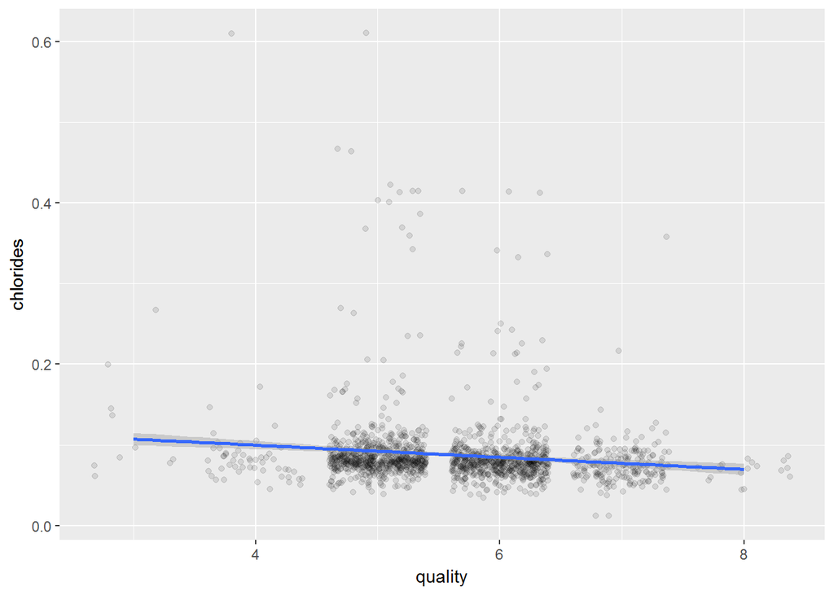

```
## df$quality: 3
##    Min. 1st Qu.  Median    Mean 3rd Qu.    Max.
##  0.0610  0.0790  0.0905  0.1225  0.1430  0.2670
## --------------------------------------------------------
## df$quality: 4
##    Min. 1st Qu.  Median    Mean 3rd Qu.    Max.
## 0.04500 0.06700 0.08000 0.09068 0.08900 0.61000
## --------------------------------------------------------
## df$quality: 5
##    Min. 1st Qu.  Median    Mean 3rd Qu.    Max.
## 0.03900 0.07400 0.08100 0.09274 0.09400 0.61100
## --------------------------------------------------------
## df$quality: 6
##    Min. 1st Qu.  Median    Mean 3rd Qu.    Max.
## 0.03400 0.06825 0.07800 0.08496 0.08800 0.41500
## --------------------------------------------------------
## df$quality: 7
##    Min. 1st Qu.  Median    Mean 3rd Qu.    Max.
## 0.01200 0.06200 0.07300 0.07659 0.08700 0.35800
## --------------------------------------------------------
## df$quality: 8
##    Min. 1st Qu.  Median    Mean 3rd Qu.    Max.
## 0.04400 0.06200 0.07050 0.06844 0.07550 0.08600
```

The chloride content is less for better quality wines

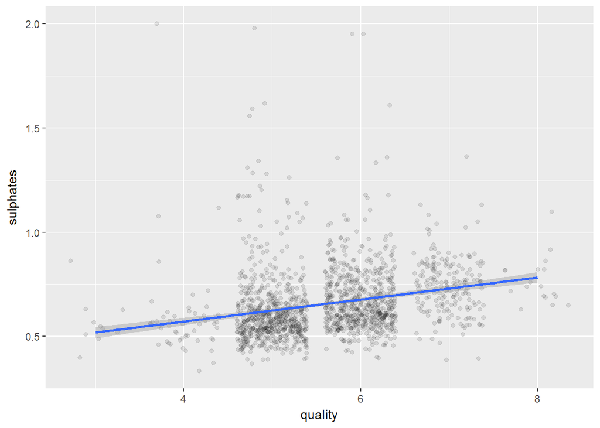

```
## df$quality: 3
##    Min. 1st Qu.  Median    Mean 3rd Qu.    Max.
##  0.4000  0.5125  0.5450  0.5700  0.6150  0.8600
## --------------------------------------------------------
## df$quality: 4
##    Min. 1st Qu.  Median    Mean 3rd Qu.    Max.
##  0.3300  0.4900  0.5600  0.5964  0.6000  2.0000
## --------------------------------------------------------
## df$quality: 5
##    Min. 1st Qu.  Median    Mean 3rd Qu.    Max.
##   0.370   0.530   0.580   0.621   0.660   1.980
## --------------------------------------------------------
## df$quality: 6
##    Min. 1st Qu.  Median    Mean 3rd Qu.    Max.
##  0.4000  0.5800  0.6400  0.6753  0.7500  1.9500
## --------------------------------------------------------
## df$quality: 7
##    Min. 1st Qu.  Median    Mean 3rd Qu.    Max.
##  0.3900  0.6500  0.7400  0.7413  0.8300  1.3600
## --------------------------------------------------------
## df$quality: 8
##    Min. 1st Qu.  Median    Mean 3rd Qu.    Max.
##  0.6300  0.6900  0.7400  0.7678  0.8200  1.1000
```

Better quality wines have more sulphate content

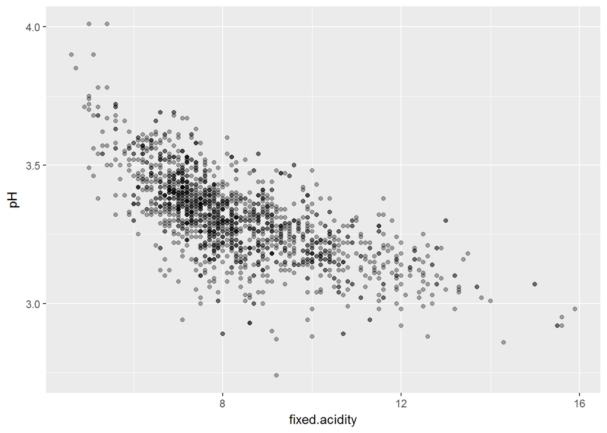

Corelation between fixed acidity and pH

```
## [1] -0.6829782
```

More the fixed acidity,lesser the pH

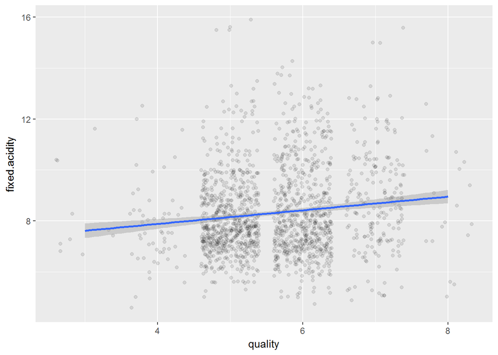

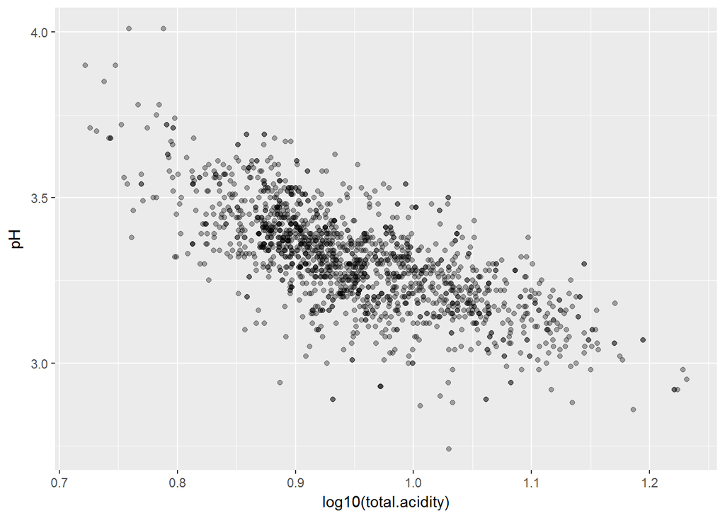

```
## [1] -0.7044435
```

Strong negative corelation observed

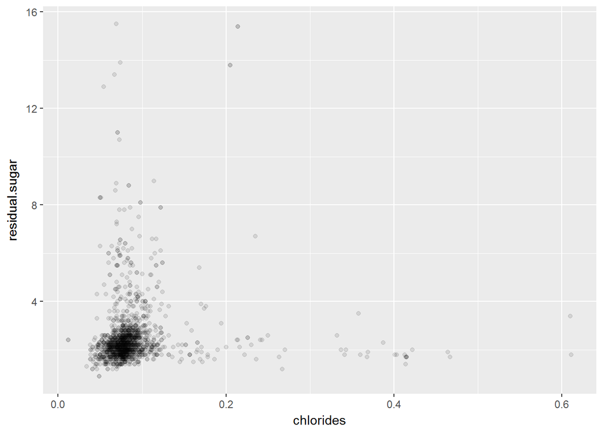

```
## [1] 0.3712605
```

A weak positive relationship between chlorides and residual sugar

# Bivariate Analysis

### Did you observe any interesting relationships between the other features (not the main feature(s) of interest)?

The most interesting relationships were between:

1.pH and fixed acidity:They are negatively corelated with a coefficient of 0.682.This is due to the well known fact that higher the acidity level,lower the pH

2.Density and alcohol:These variables are negatively corelated with a coefficient of 0.4961

### What was the strongest relationship you found?

The strongest corelation was between the total acidity content and pH levels with a Pearson’s R value of -0.7044435.ie,higher the acidity content,lower the pH

# Multivariate Plots Section

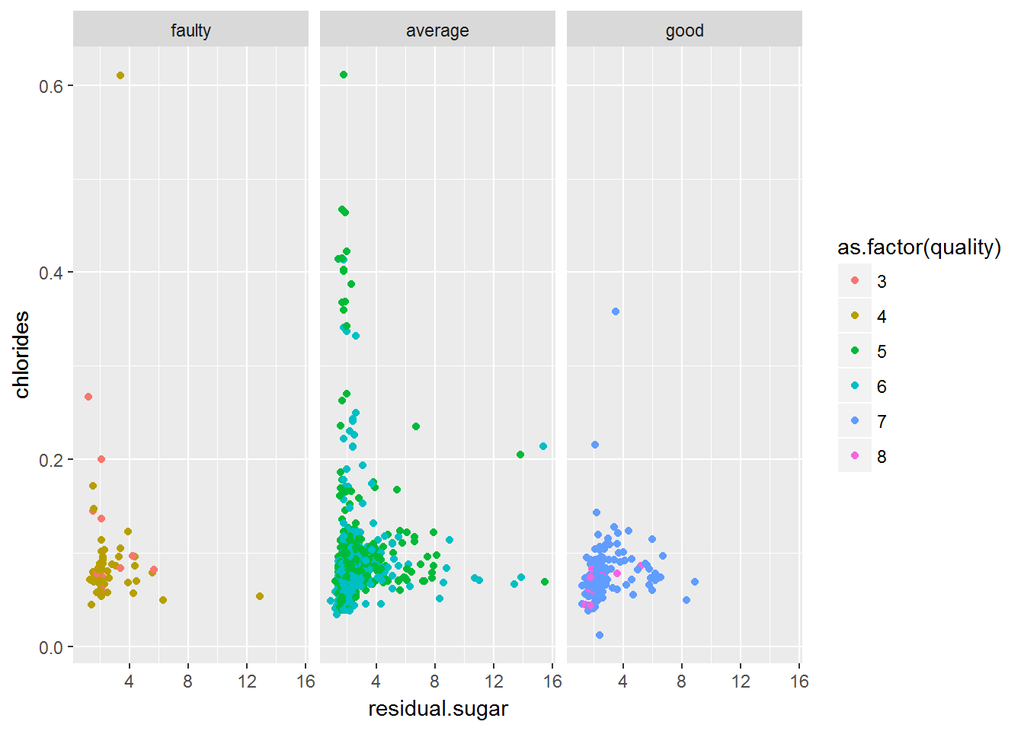

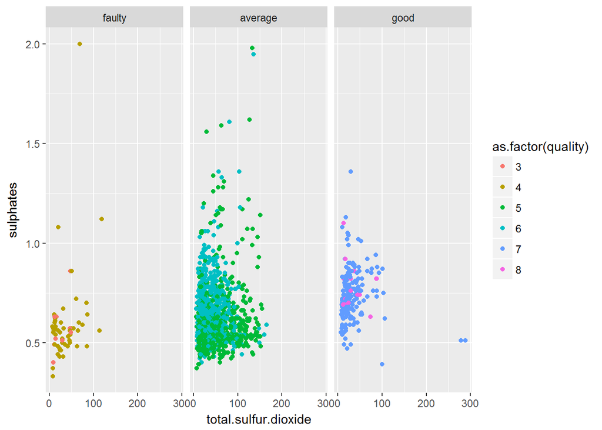

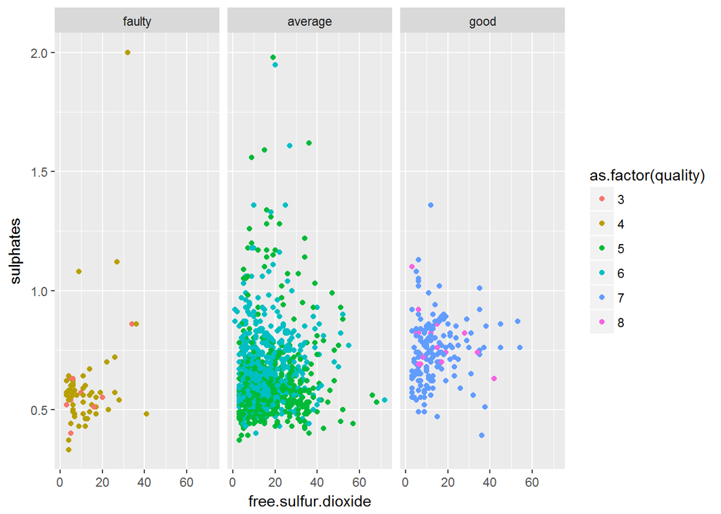

```
## df$rating: faulty
##    Min. 1st Qu.  Median    Mean 3rd Qu.    Max.
##  0.3300  0.4950  0.5600  0.5922  0.6000  2.0000
## --------------------------------------------------------
## df$rating: average
##    Min. 1st Qu.  Median    Mean 3rd Qu.    Max.
##  0.3700  0.5400  0.6100  0.6473  0.7000  1.9800
## --------------------------------------------------------
## df$rating: good
##    Min. 1st Qu.  Median    Mean 3rd Qu.    Max.
##  0.3900  0.6500  0.7400  0.7435  0.8200  1.3600
```

The sulphate content for wines are higher in the better quality wines.The good quality wines have a mean content of .7435 g/cm^3.The best quality wines have a minimum sulphate content of 0.6 g/cm^3. The total and free sulfur dioxide does not show a pattern across wine quality.Hence,it can be concluded that they do not play a key role in wine quality.

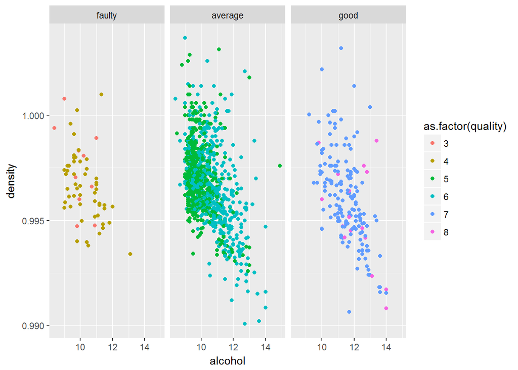

```
## df$rating: faulty
##    Min. 1st Qu.  Median    Mean 3rd Qu.    Max.
##  0.9934  0.9957  0.9966  0.9967  0.9977  1.0010
## --------------------------------------------------------
## df$rating: average
##    Min. 1st Qu.  Median    Mean 3rd Qu.    Max.
##  0.9901  0.9958  0.9968  0.9969  0.9979  1.0040
## --------------------------------------------------------
## df$rating: good
##    Min. 1st Qu.  Median    Mean 3rd Qu.    Max.
##  0.9906  0.9947  0.9957  0.9960  0.9974  1.0030
```

The alcohol content in good quality wines range between 10% and 14%.However,the density can take a range of values between 09906 and 1.0030.

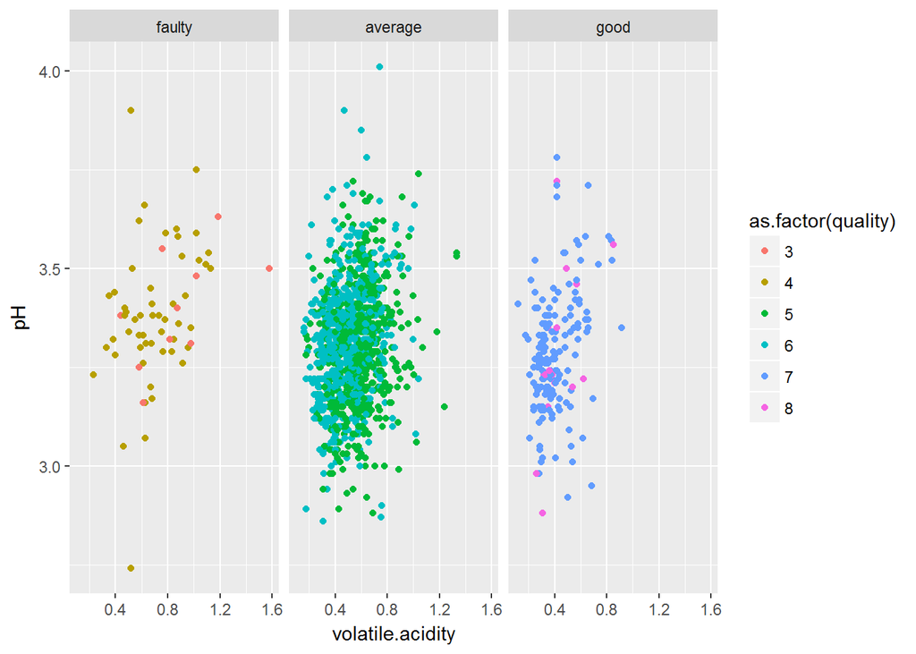

The good quality wines have volatile acidity range between 0.2 g/dm^3 and 0.8 g/dm^3.We also observe that reagrdless of the quality rating,the pH ranges are similar for all.

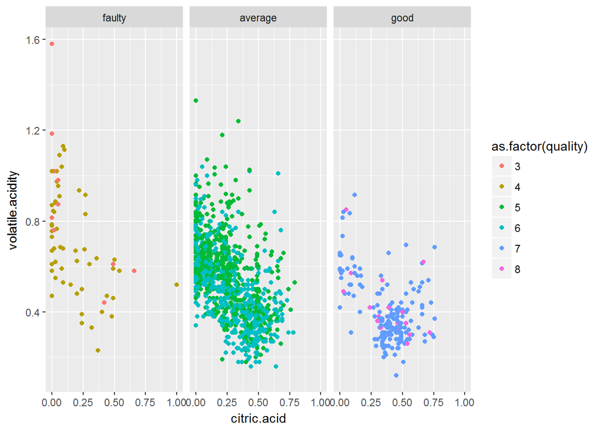

```
## df$rating: faulty
##    Min. 1st Qu.  Median    Mean 3rd Qu.    Max.
##  0.2300  0.5650  0.6800  0.7242  0.8825  1.5800
## --------------------------------------------------------
## df$rating: average
##    Min. 1st Qu.  Median    Mean 3rd Qu.    Max.
##  0.1600  0.4100  0.5400  0.5386  0.6400  1.3300
## --------------------------------------------------------
## df$rating: good
##    Min. 1st Qu.  Median    Mean 3rd Qu.    Max.
##  0.1200  0.3000  0.3700  0.4055  0.4900  0.9150
```

We can see that as the quality rating increase,the values of volatile acidity content reduces.The mean value for faulty wines is 0.7242 g/dm^3,whereas for good quality wines,it is 0.4055 g/dm^3 only.Also,we notice that the citic acid content for the faulty wines is always less than 0.5 g/dm^3,if we ignore the outliers.

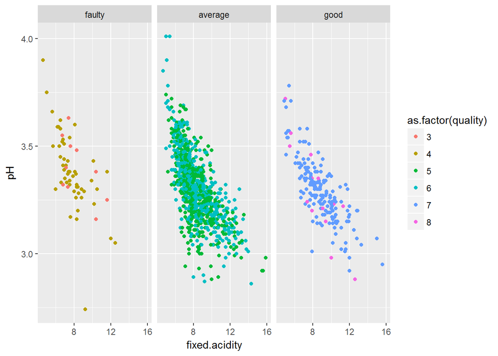

```
##    Min. 1st Qu.  Median    Mean 3rd Qu.    Max.
##   4.900   7.400   8.700   8.847  10.100  15.600
```

```
##    Min. 1st Qu.  Median    Mean 3rd Qu.    Max.
##   4.600   6.800   7.500   7.871   8.400  12.500
```

# Multivariate Analysis

### Talk about some of the relationships you observed in this part of the investigation. Were there features that strengthened each other in terms of looking at your feature(s) of interest?

After introducing a third variable,I was able to filter out the variables that mattered the most in wine quality,namely volatile acidity,sulphates,alcohol content and chlorides.The following are the main take aways from this section for good wines: 1.Higher alcohol content combined with lower density

4.Larger amount of sulphates

# Final Plots and Summary

To create the final three plots,I used the features that most directly affected the quality of wine i.e alcohol,sulphates and acidity content

### Plot One

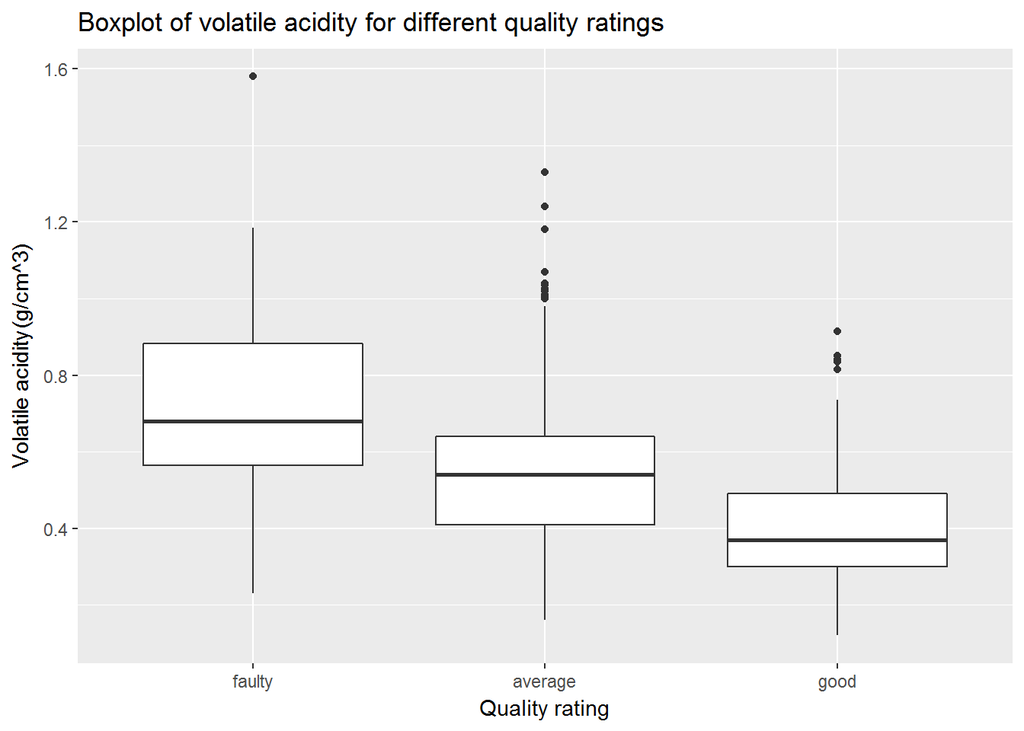

```
## df$rating: faulty
##    Min. 1st Qu.  Median    Mean 3rd Qu.    Max.
##  0.2300  0.5650  0.6800  0.7242  0.8825  1.5800
## --------------------------------------------------------
## df$rating: average
##    Min. 1st Qu.  Median    Mean 3rd Qu.    Max.
##  0.1600  0.4100  0.5400  0.5386  0.6400  1.3300
## --------------------------------------------------------
## df$rating: good
##    Min. 1st Qu.  Median    Mean 3rd Qu.    Max.
##  0.1200  0.3000  0.3700  0.4055  0.4900  0.9150
```

### Description One

There is significant decrease in the median value of volatile acidity which is 0.68 g/dm^3 for faulty wines and only 0.37 g/dm^3 for good wines.This is expected because as the amount of volatile acids like acetic acids increase,it becomes evident in the vinegar like taste of th wine.

### Plot Two

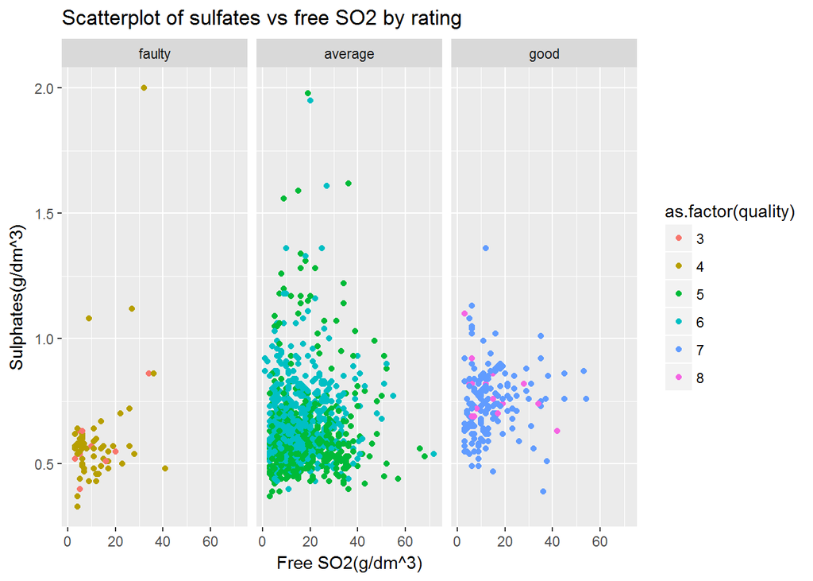

```
## df$rating: faulty
##    Min. 1st Qu.  Median    Mean 3rd Qu.    Max.
##  0.3300  0.4950  0.5600  0.5922  0.6000  2.0000
## --------------------------------------------------------
## df$rating: average
##    Min. 1st Qu.  Median    Mean 3rd Qu.    Max.
##  0.3700  0.5400  0.6100  0.6473  0.7000  1.9800
## --------------------------------------------------------
## df$rating: good
##    Min. 1st Qu.  Median    Mean 3rd Qu.    Max.
##  0.3900  0.6500  0.7400  0.7435  0.8200  1.3600
```

### Plot Three

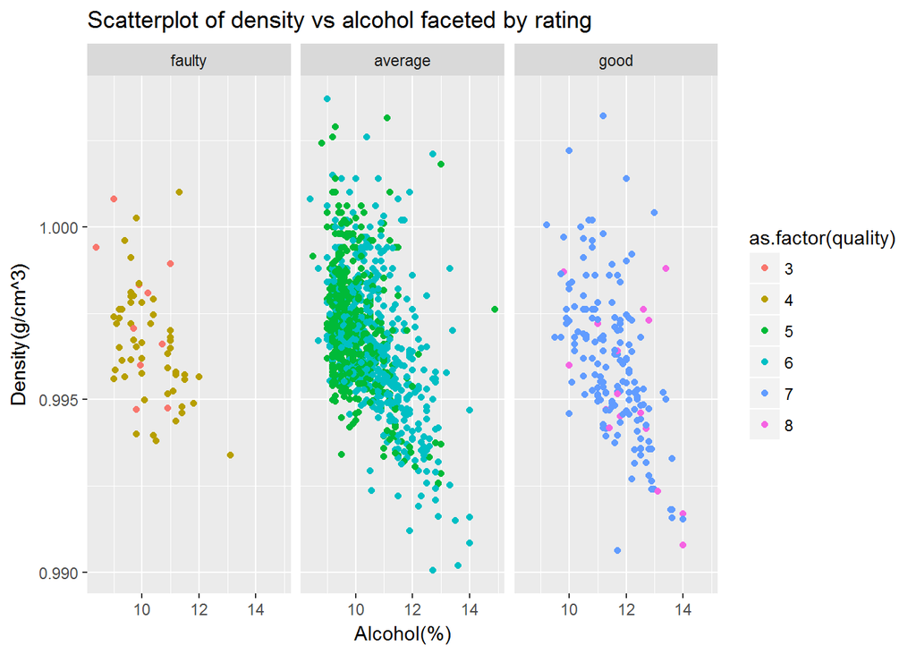

```
## df$rating: faulty
##    Min. 1st Qu.  Median    Mean 3rd Qu.    Max.
##    8.40    9.60   10.00   10.22   11.00   13.10
## --------------------------------------------------------
## df$rating: average
##    Min. 1st Qu.  Median    Mean 3rd Qu.    Max.
##    8.40    9.50   10.00   10.25   10.90   14.90
## --------------------------------------------------------
## df$rating: good
##    Min. 1st Qu.  Median    Mean 3rd Qu.    Max.
##    9.20   10.80   11.60   11.52   12.20   14.00
```

### Description Three

1.A strong negative corelation between alcohol and density i.e the density decreases with alcohol content 2.For faulty wines,the majority of samples have between 9 and 11% alcohol content whereas for good quality wines,it is between 10 and 14% 3.The mean value of alcohol for faulty wines is 10.22% and the mean value for good wines is 11.52%

# Reflection

To summarise,the important features that influence the wine quality are: 1.Acid content 2.Sulphates 3.Alcohol Thus for a good wine,we can expect the following characteristics 1.Less volatile acidity 2.Higher alcohol content 3.Higher sulphates content 4.A slightly lower pH level

Towards the beginning of the analysis,my task was to find out which of the variables represented the same chemical property.After understanding the variables,I had to group the samples based on quality scores because otherwise, it will be difficult to detect the trends across each score.So three categories were created:‘Faulty’,‘Average’ and ‘Good’.Then distribution of variables were studied by using histograms,how the quality varied with variables were studied using categorical scatterplots and multivariable analysis was also carried inorder to detect other hidden differences in the variables across ratings .However,to confirm these assertions,further statistical tests needed to be conducted. Wine quality never comes down to a single factor. Color, structure, flavor and typicity are all important.